# Basic Usage

```r
library(dplyr)
library(tidyr)
library(lubridate)
library(frenchdata)
library(ggplot2)
```

The `frenchdata` package provides functions to download the finance data sets provided by the [data library website](http://mba.tuck.dartmouth.edu/pages/faculty/ken.french/data_library.html) of Prof. Kenneth French.

We can visit the website using the function:

```r
browse_french_site()
```

this will open the page on your default browser.

As a first step we get the list of data sets that are currently available to download:

```r
data_sets <- get_french_data_list()
```

The `get_french_data_list()` function returns an object of the S3 class `french_data_list`:

```r
data_sets
```

```
#>
#> ── Kenneth's French data library
#> ℹ Information collected from: https://mba.tuck.dartmouth.edu/pages/faculty/ken.french/data_library.html on Wed Sep 08 20:48:59 2021
#>
#> ── Files list
#> # A tibble: 297 × 3
#>    name                                                file_url details_url
#>    <chr>                                               <chr>    <chr>
#>  1 Fama/French 3 Factors                               ftp/F-F… Data_Libra…
#>  2 Fama/French 3 Factors [Weekly]                      ftp/F-F… Data_Libra…
#>  3 Fama/French 3 Factors [Daily]                       ftp/F-F… Data_Libra…
#>  4 Fama/French 5 Factors (2x3)                         ftp/F-F… Data_Libra…
#>  5 Fama/French 5 Factors (2x3) [Daily]                 ftp/F-F… Data_Libra…
#>  6 Portfolios Formed on Size                           ftp/Por… Data_Libra…
#>  7 Portfolios Formed on Size [ex.Dividends]            ftp/Por… Data_Libra…
#>  8 Portfolios Formed on Size [Daily]                   ftp/Por… Data_Libra…
#>  9 Portfolios Formed on Book-to-Market                 ftp/Por… Data_Libra…
#> 10 Portfolios Formed on Book-to-Market [ex. Dividends] ftp/Por… Data_Libra…
#> # … with 287 more rows
```

## Searching for a data set

To download a data set we need to identify its name first from the list `data_sets` obtained previously. A simple way of performing this search is to use the `View()` function provided by RStudio on the `files_list` element that contains the the files list:

```r
View(data_sets$files_list)
```

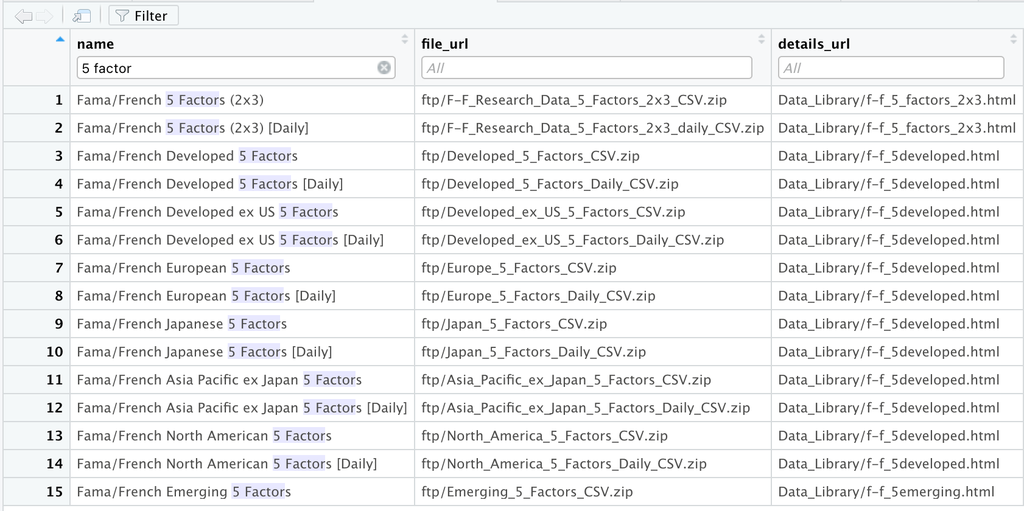

Using the filter on Rstudio viewer

and use the filter to narrow down the search, for instance if I’m looking for the 5 factors I can quickly identify the correct data set name.

## Downloading a data set

To download a specific data, for instance the monthly Fama/French 5 Factors (2x3) set we can use:

```r
ff_5_factors <-
  download_french_data("Fama/French 5 Factors (2x3)")
```

```
#> * `` -> ...1
#> * `` -> ...1
```

This will return an object of class `french_dataset`:

```r
ff_5_factors
```

```
#>
#> ── Kenneth's French data set
#> ℹ This file was created by CMPT_ME_BEME_OP_INV_RETS using the 202106 CRSP database. The 1-month TBill return is from Ibbotson and Associates Inc.
#>
#> Information collected from: https://mba.tuck.dartmouth.edu/pages/faculty/ken.french/ftp/F-F_Research_Data_5_Factors_2x3_CSV.zip on Wed Sep 08 20:57:17 2021
#>
#> ℹ For details on the data set call the function `browse_details_page()` on this object
#>
#> ── Subsets in the file:
#> # A tibble: 2 × 2
#>   name                               data
#>   <chr>                              <list>
#> 1 ""                                 <spec_tbl_df [696 × 7]>
#> 2 "Annual Factors: January-December" <spec_tbl_df [57 × 7]>
```

The file contains two subsets of data:

```r
ff_5_factors$subsets
```

```
#> # A tibble: 2 × 2
#>   name                               data
#>   <chr>                              <list>
#> 1 ""                                 <spec_tbl_df [696 × 7]>
#> 2 "Annual Factors: January-December" <spec_tbl_df [57 × 7]>
```

The first one is the default one and is unnamed, and the second one is on “Annual Factors: January-December”. We can access the data on the first subset:

```r
monthly_ff_5_factors <- ff_5_factors$subsets$data[[1]]
monthly_ff_5_factors
```

```
#> # A tibble: 696 × 7
#>      date `Mkt-RF`   SMB   HML   RMW   CMA    RF
#>     <dbl>    <dbl> <dbl> <dbl> <dbl> <dbl> <dbl>
#>  1 196307    -0.39 -0.45 -0.94  0.66 -1.15  0.27
#>  2 196308     5.07 -0.82  1.82  0.4  -0.4   0.25
#>  3 196309    -1.57 -0.48  0.17 -0.76  0.24  0.27
#>  4 196310     2.53 -1.3  -0.04  2.75 -2.24  0.29
#>  5 196311    -0.85 -0.85  1.7  -0.45  2.22  0.27
#>  6 196312     1.83 -1.9  -0.06  0.07 -0.3   0.29
#>  7 196401     2.24  0.08  1.53  0.22  1.5   0.3
#>  8 196402     1.54  0.31  2.86  0.06  0.85  0.26
#>  9 196403     1.41  1.4   3.37 -2.01  2.93  0.31
#> 10 196404     0.1  -1.5  -0.66 -1.35 -1.08  0.29
#> # … with 686 more rows
```

We can now browse use this data.frame directly, for instance, to plot all each of the factors and the risk-free rate overtime:

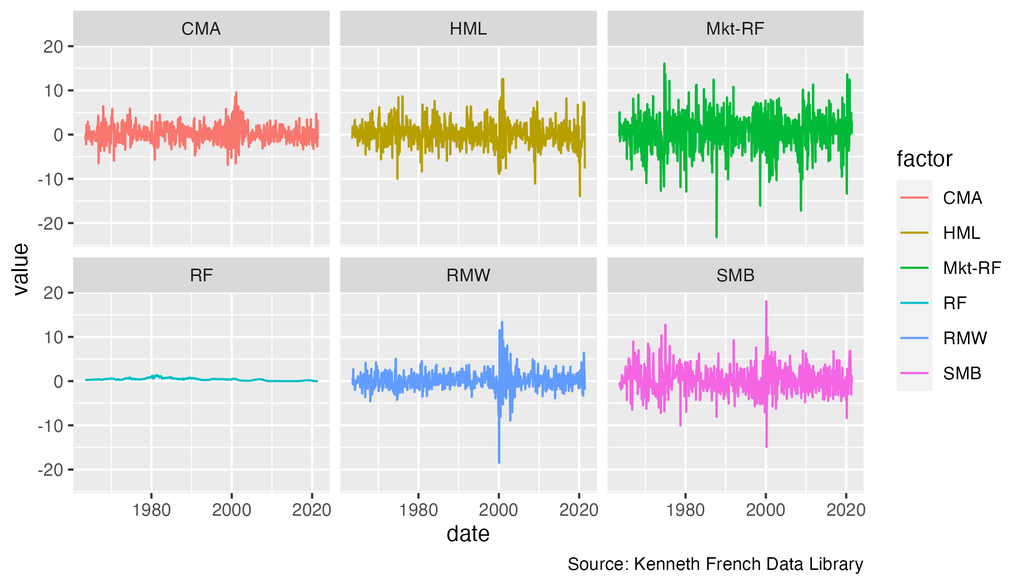

```r
monthly_ff_5_factors %>%
  mutate(date = ym(date)) %>%
  pivot_longer(cols = -date,
               names_to = "factor",
               values_to = "value") %>%
  ggplot(data = .,
         mapping = aes(x = date, y = value,
                       group = factor,
                       color = factor)) +
  geom_line() +
  labs(caption = "Source: Kenneth French Data Library") +
  facet_wrap( ~ factor)
```

We can browse the details page for this specific data set using:

```r
browse_details_page(ff_5_factors)
```

## Downloading and saving a data set

```r
ff_5_factors <-
  download_french_data("Fama/French 5 Factors (2x3)",
                       dir = ".",
                       dest_file = "fama_french_5_factors.zip")
```

This will download the file, read it, assign the result to the object `ff_5_factors`, and save the results to the file `fama_french_5_factors.zip` on the current directory.

If we prefer to use the original file name just leave the `dest_file` parameter unset:

```r
ff_5_factors <-
  download_french_data("Fama/French 5 Factors (2x3)",
                       dir = ".")
```